# cyclist

Franklin Aguilar

2/17/2022

# Ciclismo Casual y Premium

## Objetivo del analisis

El objetivo de este análisis es descubrir los patrones de uso de los consumidores casuales de los premium. De esta forma se podría saber bajo que condiciones el consumidor elige una suscripción en comparación a otra y tratar de aplicar esas ideas para convencer a un usuario casual de se suscriba a la versión premium.

¿Lo lograre? No tengo idea, pero vamos con todos los huevos a describirlo!!!

## Sobre la data

La data de este proyecto contiene la información de los viajes de los usuarios del servicio de alquiler de bicicletas divvy entre los meses de enero de 2021 y enero de 2022. La data es de origen publico y es posible descargarlo del siguiente enlace:

https://divvy-tripdata.s3.amazonaws.com/index.html

## Primeros Pasos

```r
setwd("/Users/franklinaguilar/Documents/Github/cyclist")
library(tidyverse)
library(dplyr)
data_0 <- read.csv("tripdata.csv")
```

Quitamos filas con contenido vacio. Solo voy a trabajar con 2 columnas, asi que me voy a concentrar esas.

Fuente: https://www.diegocalvo.es/eliminar-na-o-valores-nulos-en-r/

```r
data_0 <- data_0[!is.na(data_0$ended_at),]
data_0 <- data_0[!is.na(data_0$started_at),]
```

Al parecer esa columnas están bien rellenadas

Vamos a crear una columna nueva con la duración del viaje.

```r
library(lubridate)
data_1 <- data_0 %>%
  mutate(ride_length=as.duration(started_at %--% ended_at))
```

Vamos a crear una columna etiquetando las duraciones en grupos.

```r
data_2 <- data_1 %>%
  mutate(rango = ifelse(data_1$ride_length < 0, "min_negativos",
                 ifelse(data_1$ride_length == 0, "min00_ceros",
                 ifelse(data_1$ride_length > 0 & data_1$ride_length <= 60, "min00_min01",
                 ifelse(data_1$ride_length > 60 & data_1$ride_length <= 300, "min01_min05",
                 ifelse(data_1$ride_length > 300 & data_1$ride_length <= 600, "min05_min10",
                 ifelse(data_1$ride_length > 600 & data_1$ride_length <= 900, "min10_min15",
                 ifelse(data_1$ride_length > 900 & data_1$ride_length <= 1800, "min15_min30",
                 ifelse(data_1$ride_length > 1800 & data_1$ride_length <= 3600, "min30_min60",
                        "min60_a_mas")))))))))
```

Vamos a ver los valores de la duración

```r
resumen <- data_2 %>%
  group_by(rango) %>%
  summarise(cantidad = length(rango),
            valor_min = min(ride_length),
            promedio = mean(ride_length),
            valor_max = max(ride_length))

library(knitr)
kable(resumen)
```

| rango | cantidad | valor_min | promedio | valor_max |
| --- | --- | --- | --- | --- |
| min_negativos | 147 | -3482 | -930.43537 | -1 |
| min00_ceros | 511 | 0 | 0.00000 | 0 |
| min00_min01 | 87321 | 1 | 24.57804 | 60 |
| min01_min05 | 798382 | 61 | 210.84222 | 300 |
| min05_min10 | 1507136 | 301 | 445.22459 | 600 |
| min10_min15 | 1054829 | 601 | 739.22737 | 900 |
| min15_min30 | 1404139 | 901 | 1262.45848 | 1800 |
| min30_min60 | 596718 | 1801 | 2410.37130 | 3600 |
| min60_a_mas | 249650 | 3601 | 10521.63182 | 3356649 |

Hay resultados negativos y eso no puede ser.

Hay un par de valores negativos que debo quitar de la base de datos. No es posible que exista un valor negativo (a menos que los ciclistas viajen en el tiempo y la ultima vez que investigue eso aun no se puede realizar). También quiero sacar los valores cercanos o iguales a cero porque son casos tan fugaces que son irrelevantes. Sospecho que estos valores cercanos a cero son de personas que estaban a punto de salir y se arrepintieron.

Solo nos quedamos con valores positivos

```r
data_2 <- data_2[data_2$ride_length > 0,]
```

```r
resumen_2 <- data_2 %>%
  group_by(rango) %>%
  summarise(cantidad = length(rango),
            valor_min = min(ride_length),
            promedio = mean(ride_length),
            valor_max = max(ride_length))

library(knitr)
kable(resumen_2)
```

| rango | cantidad | valor_min | promedio | valor_max |
| --- | --- | --- | --- | --- |
| min00_min01 | 87321 | 1 | 24.57804 | 60 |
| min01_min05 | 798382 | 61 | 210.84222 | 300 |
| min05_min10 | 1507136 | 301 | 445.22459 | 600 |
| min10_min15 | 1054829 | 601 | 739.22737 | 900 |
| min15_min30 | 1404139 | 901 | 1262.45848 | 1800 |
| min30_min60 | 596718 | 1801 | 2410.37130 | 3600 |
| min60_a_mas | 249650 | 3601 | 10521.63182 | 3356649 |

Bacán ahora solo vamos a trabajar con viajes positivos de al menos 1 segundo en adelante.

La mayoría de usuarios usa su bicicleta entre 5 y 10 minutos (min05_min10). Sin embargo, hay otro pico relevante entre el minuto 15 y 30 (min15_min30). Este ultimo intervalo está a medio camino de un transporte cercano y hacer deporte.

Finalmente una estrepitosa menor cantidad de usuarios usan su bicicleta mas de 1 hora. Considero que este intervalo están aquellos usuarios que realizan ejercicio o realizan entregas delivery, etc.

Pagina de referencia https://gt.rstudio.com/reference/fmt_datetime.html

Agregamos una columna adicional con los nombre de los dias de la semana, para saber que dia es el dia mas popular para realizar viajes en bicicleta.

```r
library(lubridate)
data_3 <- data_2 %>%
  mutate (day_of_week=weekdays(as.Date(started_at)))

# Estrictamente lo que se requería era:
# % mutate(day_of_week=as.numeric(format(as.Date(started_at), format = "%u")))
# Pero para resumir la información me sirve mejor tener "Monday" a "1"
```

## Analisis

Seria bueno saber los días mas populares para salir con la bicicleta.

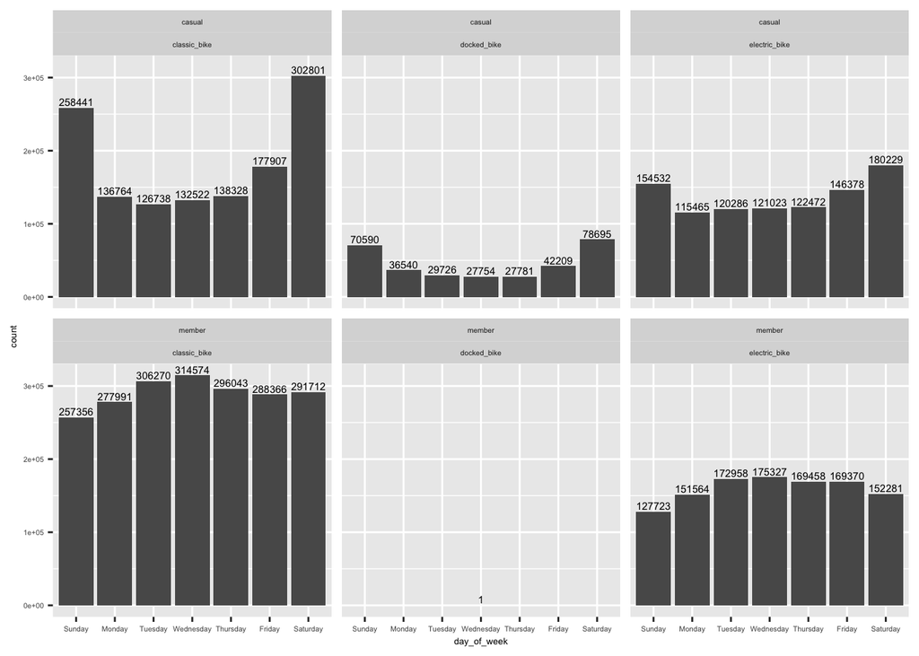

```r
library(ggplot2)
library(tidyverse)

data_3$day_of_week <- factor(data_3$day_of_week,
levels = c('Sunday','Monday','Tuesday','Wednesday','Thursday','Friday','Saturday'))

ggplot(data = data_3,aes(x=day_of_week)) +
  geom_bar() +
  geom_text(aes(label = ..count..), stat = "count", vjust = -0.3, colour = "black", size=2) +
  theme(text = element_text(size = 5)) +
  facet_wrap(~member_casual + rideable_type)
```

Me gustaría saber como pintar las columnas de forma independiente, pero ya lo hare para futuros proyectos. Dejo un link interesante que podria servirme en un futuro. https://www.cedricscherer.com/2021/07/05/a-quick-how-to-on-labelling-bar-graphs-in-ggplot2/

Retomando el analisis, los usuarios casuales utilizan el servicio con intensidad los sábados y domingos. A diferencia de los usuarios premium cuyo uso crece durante la semana a partir del martes.

```r
resumen_3 <- data_3 %>%
  group_by(member_casual) %>%
  summarise(cantidad = length(rango),
            valor_min = min(ride_length),
            promedio = mean(ride_length),
            valor_max = max(ride_length))

library(knitr)
kable(resumen_3)
```

| member_casual | cantidad | valor_min | promedio | valor_max |
| --- | --- | --- | --- | --- |
| casual | 2547181 | 1 | 1919.6387 | 3356649 |
| member | 3150994 | 1 | 815.3899 | 93596 |

Por otro lado, el usuario casual utiliza en menor cantidad el servicio en comparación del usuario premium.

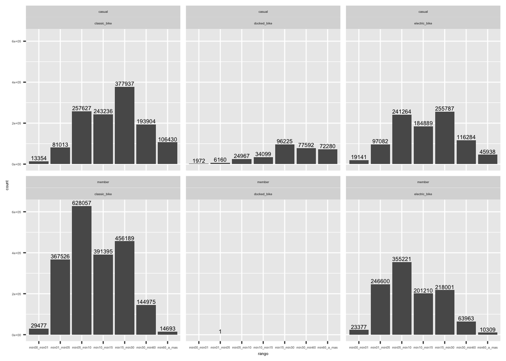

```r
library(ggplot2)
library(tidyverse)

ggplot(data = data_3,aes(x=rango)) +
  geom_bar() +
  geom_text(aes(label = ..count..), stat = "count", vjust = -0.3, colour = "black", size=2) +
  theme(text = element_text(size = 4)) +
  facet_wrap(~member_casual + rideable_type)
```

Eureka! Aquí esta algo interesante. Podemos ver que lo usuarios premium no utilizan el servicio de docked_bike.

## Recomendaciones

Yo recomendaría a la gerencia que si quiere que los usuarios casuales a premium que reoriente sus esfuerzos en promociones para el uso de docked_bike.